# Purpose

This script pre-processes the training and validation data for modeling water temperature in Shadow Mountain Reservoir and saves column means/standard deviations used to pre-process so we can apply to testing data, too.

# Setup environment

```r
source('pySetup.R')
```

```python
# import modules
import os
import sys
import pandas as pd
import numpy as np
from plotnine import ggplot, geom_point, geom_histogram, aes, facet_grid, theme_bw, labs
from datetime import date
import datetime as dt
import pickle

# store a date for versioning
standardize_version = '2024-05-21'
```

# Load files!

```python
file_path = os.path.expanduser("/Users/steeleb/OneDrive - Colostate/NASA-Northern/data/NN_train_val_test/SMR_autoNN_daily/")

# list the files and get the set that use the test as 2023:
files = pd.Series(os.listdir(file_path))
files = files[files.str.contains('t2023')]
# we just care about the train/val set right now
tv = files[files.str.contains('trainval')]
idx = tv.index

# import training data
tv_fn = os.path.join(file_path, tv[idx[0]])
with open(tv_fn) as f:
    tv = pd.read_csv(f, sep=',')
```

# Transform as needed

We should look at the histograms for these variables to know if we need to transform before standardizing.

### Water Temperature:

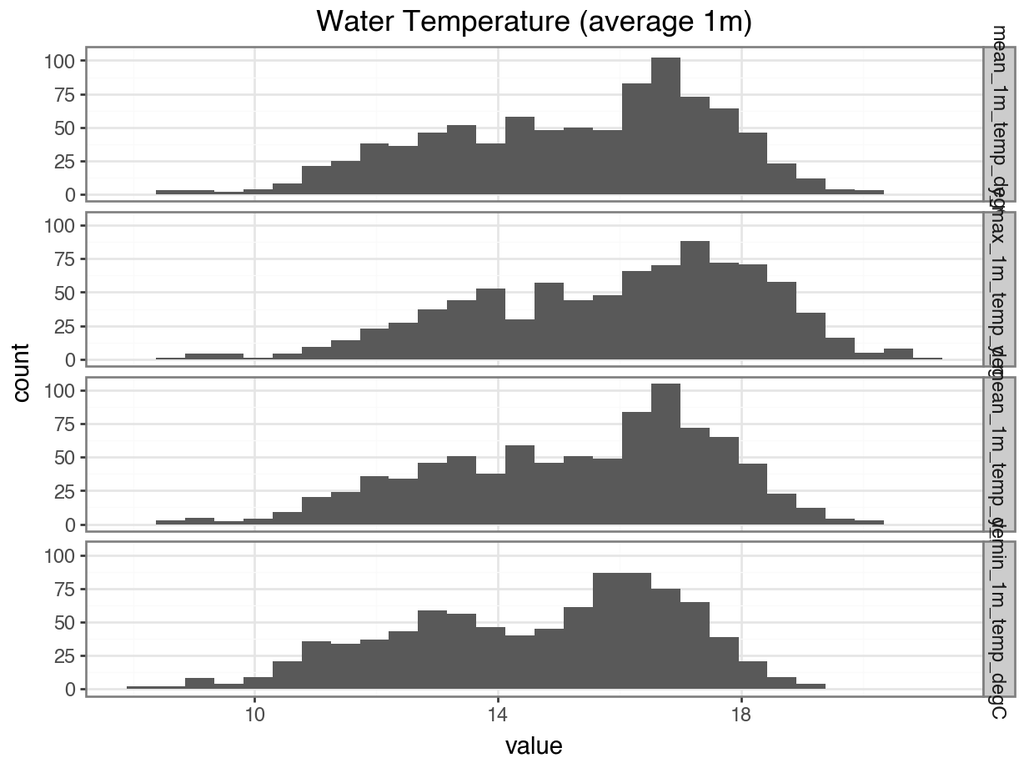

```python
h20_1m_temp = (pd.DataFrame(tv.filter(like='1m').stack())
              .reset_index(drop=False)
              .rename(columns={'level_0':'rowid', 'level_1':'variable', 0:'value'}))
(ggplot(h20_1m_temp, aes(x = 'value'))
  + geom_histogram()
  + labs(title = "Water Temperature (average 1m)")
  + facet_grid(rows = 'variable')
  + theme_bw()
  )
```

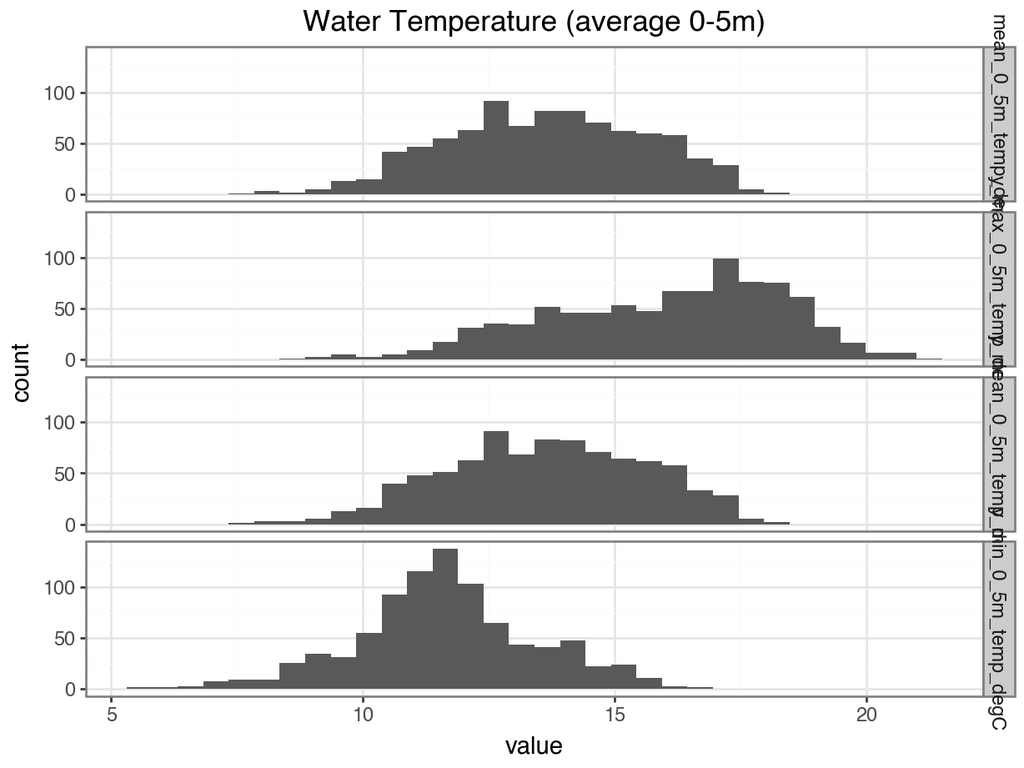

```python
h20_05m_temp = (pd.DataFrame(tv.filter(like='0_5m').stack())
              .reset_index(drop=False)
              .rename(columns={'level_0':'rowid', 'level_1':'variable', 0:'value'}))
(ggplot(h20_05m_temp, aes(x = 'value'))
  + geom_histogram()
  + labs(title = "Water Temperature (average 0-5m)")
  + facet_grid(rows = 'variable')
  + theme_bw()
  )
```

These are nearly bi-modal, but we’ll leave as is.

### Air Temperature:

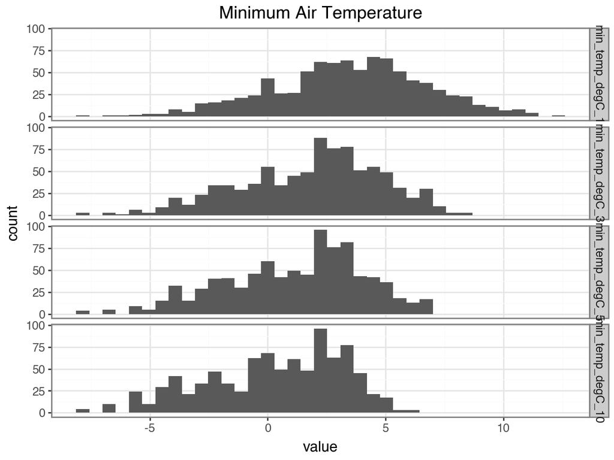

```python
min_temp = (pd.DataFrame(tv.filter(like='min_temp').stack())
              .reset_index(drop=False)
              .rename(columns={'level_0':'rowid', 'level_1':'variable', 0:'value'}))
min_temp['variable'] = min_temp['variable'].astype('category').cat.reorder_categories(['min_temp_degC_1', 'min_temp_degC_3', 'min_temp_degC_5', 'min_temp_degC_10'])
mean_temp = (pd.DataFrame(tv.filter(like='mean_temp').stack())
              .reset_index(drop=False)
              .rename(columns={'level_0':'rowid', 'level_1':'variable', 0:'value'})
              .sort_values('variable'))
mean_temp['variable'] = mean_temp['variable'].astype('category').cat.reorder_categories(['mean_temp_degC_1', 'mean_temp_degC_3', 'mean_temp_degC_5', 'mean_temp_degC_10'])
max_temp = (pd.DataFrame(tv.filter(like='max_temp').stack())
              .reset_index(drop=False)
              .rename(columns={'level_0':'rowid', 'level_1':'variable', 0:'value'})
              .sort_values('variable'))
max_temp['variable'] = max_temp['variable'].astype('category').cat.reorder_categories(['max_temp_degC_1', 'max_temp_degC_3', 'max_temp_degC_5', 'max_temp_degC_10'])

(ggplot(min_temp, aes(x = 'value'))
  + geom_histogram()
  + labs(title = "Minimum Air Temperature")
  + facet_grid(rows = 'variable')
  + theme_bw()
  )
```

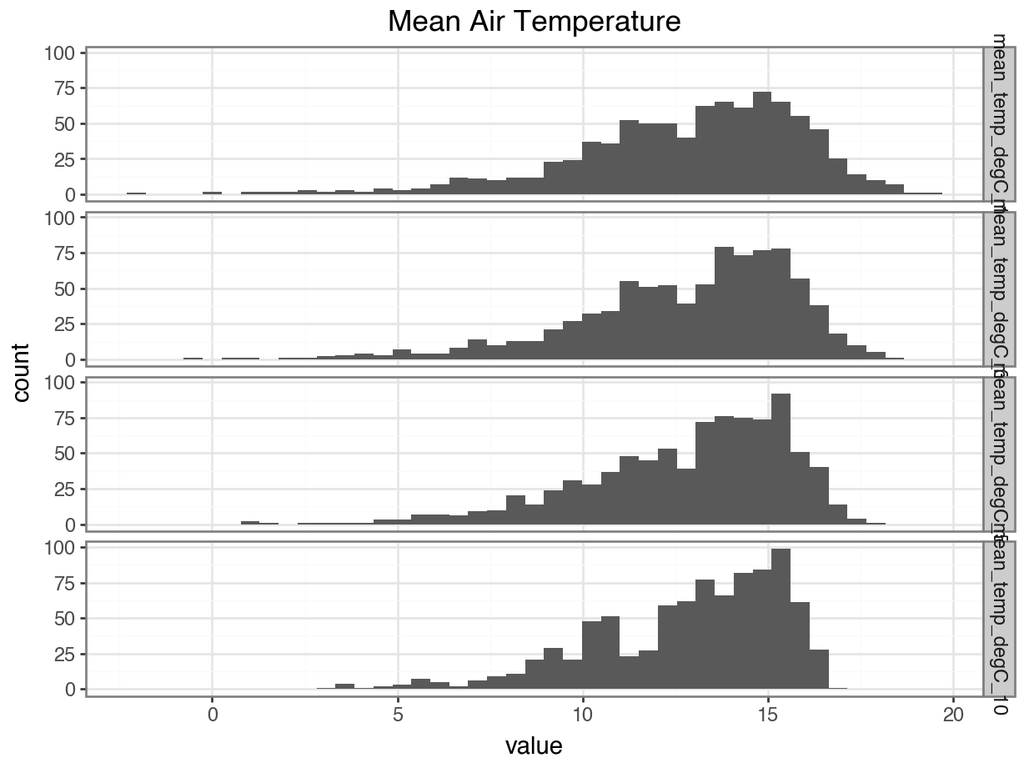

```python
(ggplot(mean_temp, aes(x = 'value'))
  + geom_histogram()
  + labs(title = "Mean Air Temperature")
  + facet_grid(rows = 'variable')
  + theme_bw()
  )
```

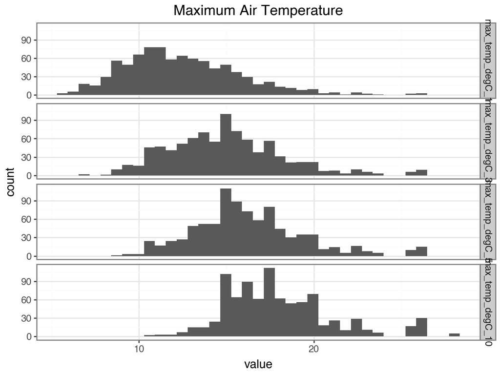

```python
(ggplot(max_temp, aes(x = 'value'))
  + geom_histogram()
  + labs(title = "Maximum Air Temperature")
  + facet_grid(rows = 'variable')
  + theme_bw()
  )
```

These are a little skewed (mean air temp in particulary), but not enough to warrant transformation.

### Wind

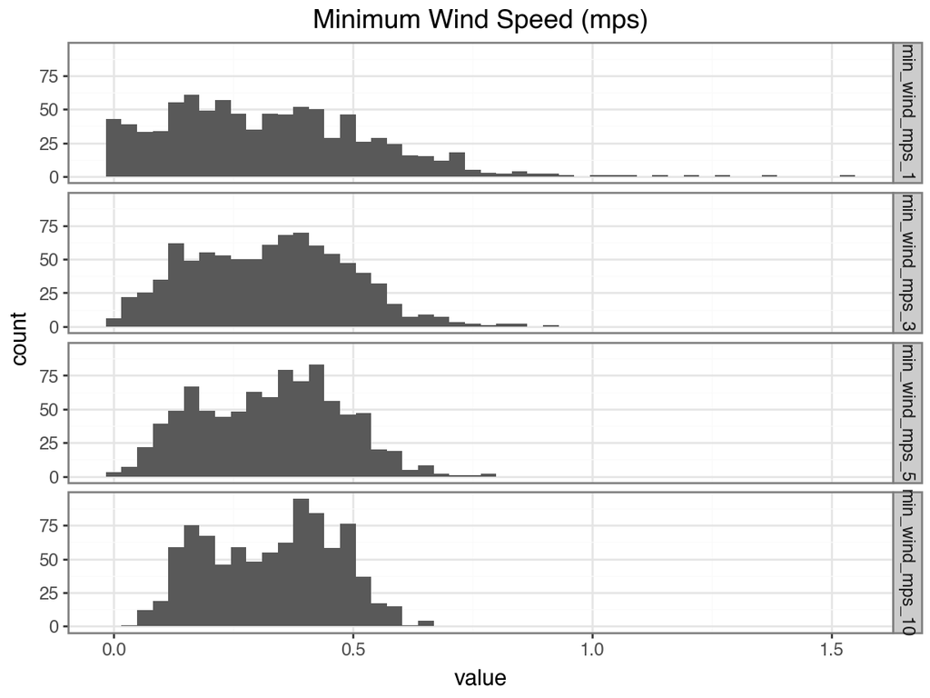

```python
min_wind = (pd.DataFrame(tv.filter(like='min_wind').stack())
              .reset_index(drop=False)
              .rename(columns={'level_0':'rowid', 'level_1':'variable', 0:'value'}))
min_wind['variable'] = min_wind['variable'].astype('category').cat.reorder_categories(['min_wind_mps_1', 'min_wind_mps_3', 'min_wind_mps_5', 'min_wind_mps_10'])
mean_wind = (pd.DataFrame(tv.filter(like='mean_wind').stack())
              .reset_index(drop=False)
              .rename(columns={'level_0':'rowid', 'level_1':'variable', 0:'value'}))
mean_wind['variable'] = mean_wind['variable'].astype('category').cat.reorder_categories(['mean_wind_mps_1', 'mean_wind_mps_3', 'mean_wind_mps_5', 'mean_wind_mps_10'])
max_wind = (pd.DataFrame(tv.filter(like='max_wind').stack())
              .reset_index(drop=False)
              .rename(columns={'level_0':'rowid', 'level_1':'variable', 0:'value'}))
max_wind['variable'] = max_wind['variable'].astype('category').cat.reorder_categories(['max_wind_mps_1', 'max_wind_mps_3', 'max_wind_mps_5', 'max_wind_mps_10'])

(ggplot(min_wind, aes(x = 'value'))
  + geom_histogram()
  + labs(title = "Minimum Wind Speed (mps)")
  + facet_grid(rows = 'variable')
  + theme_bw()
  )
```

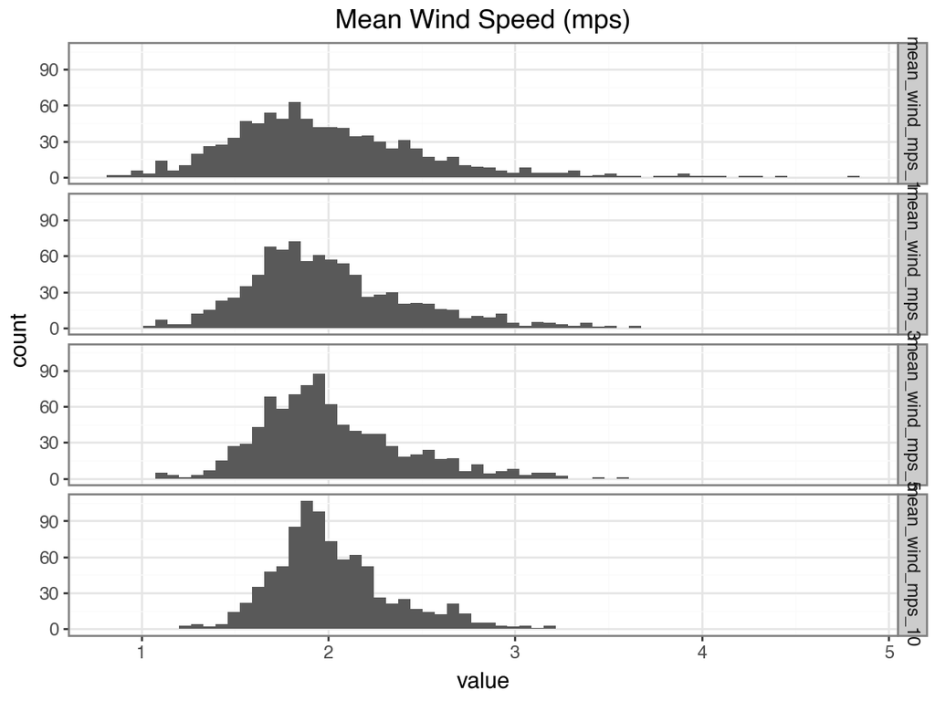

```python
(ggplot(mean_wind, aes(x = 'value'))
  + geom_histogram()
  + labs(title = "Mean Wind Speed (mps)")
  + facet_grid(rows = 'variable')
  + theme_bw()
  )
```

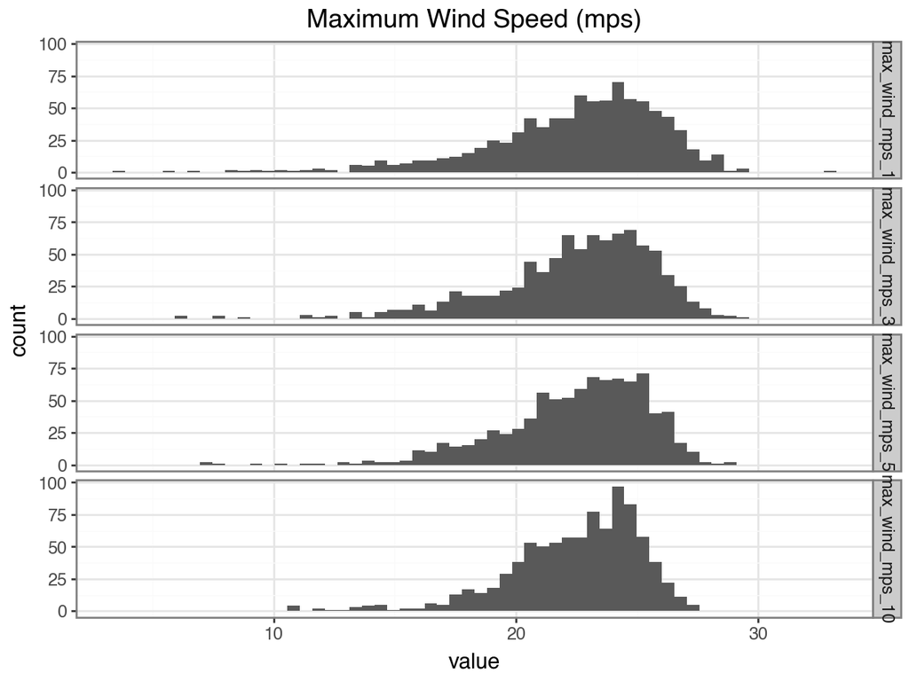

```python
(ggplot(max_wind, aes(x = 'value'))
  + geom_histogram()
  + labs(title = "Maximum Wind Speed (mps)")
  + facet_grid(rows = 'variable')
  + theme_bw()
  )
```

It looks like maximum wind variables need to be transformed here.

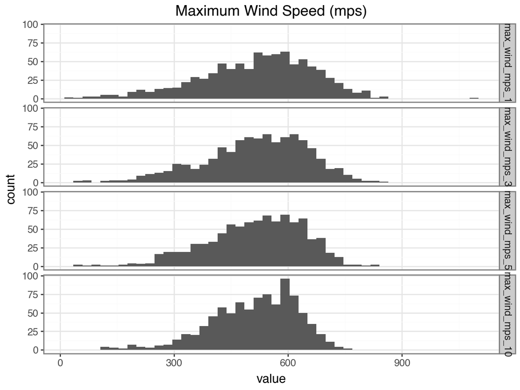

```python
tv_no_max_wind = tv.drop(tv.filter(like = 'max_wind').columns, axis = 1)
max_wind = tv.filter(like = 'max_wind')
max_wind = np.square(max_wind)

tv2 = pd.concat([tv_no_max_wind, max_wind], axis = 1)

max_wind = (pd.DataFrame(tv2.filter(like='max_wind').stack())
              .reset_index(drop=False)
              .rename(columns={'level_0':'rowid', 'level_1':'variable', 0:'value'}))
max_wind['variable'] = max_wind['variable'].astype('category').cat.reorder_categories(['max_wind_mps_1', 'max_wind_mps_3', 'max_wind_mps_5', 'max_wind_mps_10'])

(ggplot(max_wind, aes(x = 'value'))
  + geom_histogram()
  + labs(title = "Maximum Wind Speed (mps)")
  + facet_grid(rows = 'variable')
  + theme_bw()
  )
```

That’s a little better.

### Solar Radiation

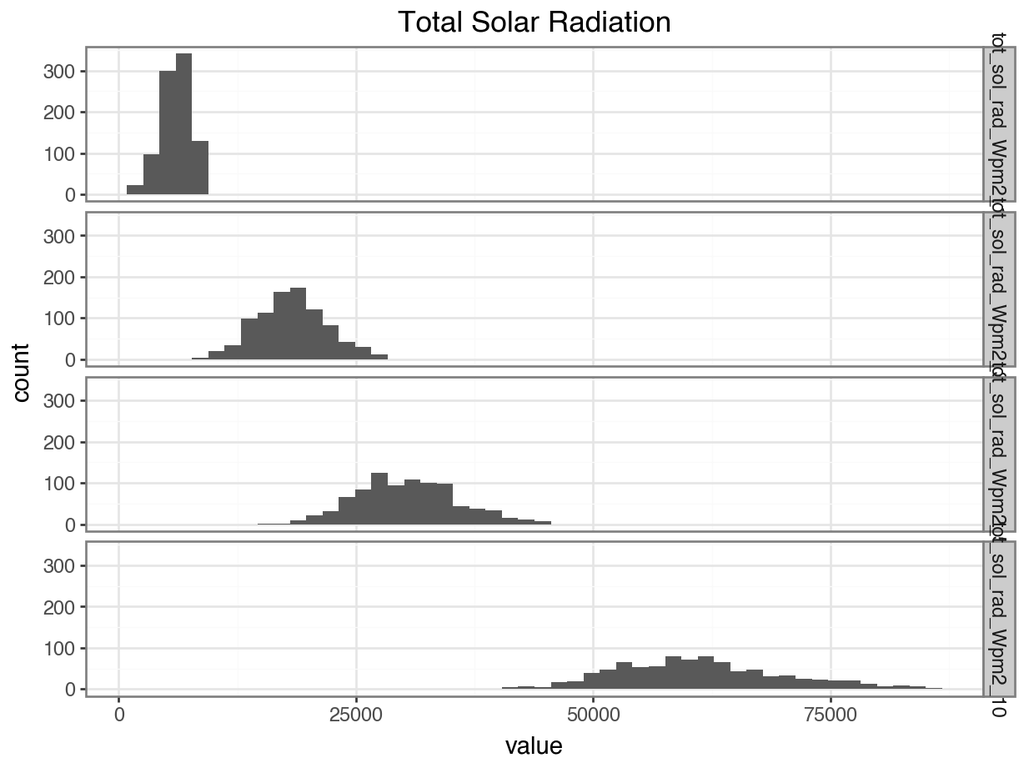

```python
tot_sol_rad = (pd.DataFrame(tv.filter(like='sol_rad').stack())
              .reset_index(drop=False)
              .rename(columns={'level_0':'rowid', 'level_1':'variable', 0:'value'}))
tot_sol_rad['variable'] = tot_sol_rad['variable'].astype('category').cat.reorder_categories(['tot_sol_rad_Wpm2_1', 'tot_sol_rad_Wpm2_3', 'tot_sol_rad_Wpm2_5', 'tot_sol_rad_Wpm2_10'])

(ggplot(tot_sol_rad, aes(x = 'value'))
  + geom_histogram(bins = 50)
  + labs(title = "Total Solar Radiation")
  + facet_grid(rows = 'variable')
  + theme_bw()
  )
```

These look fine!

### Precipitation

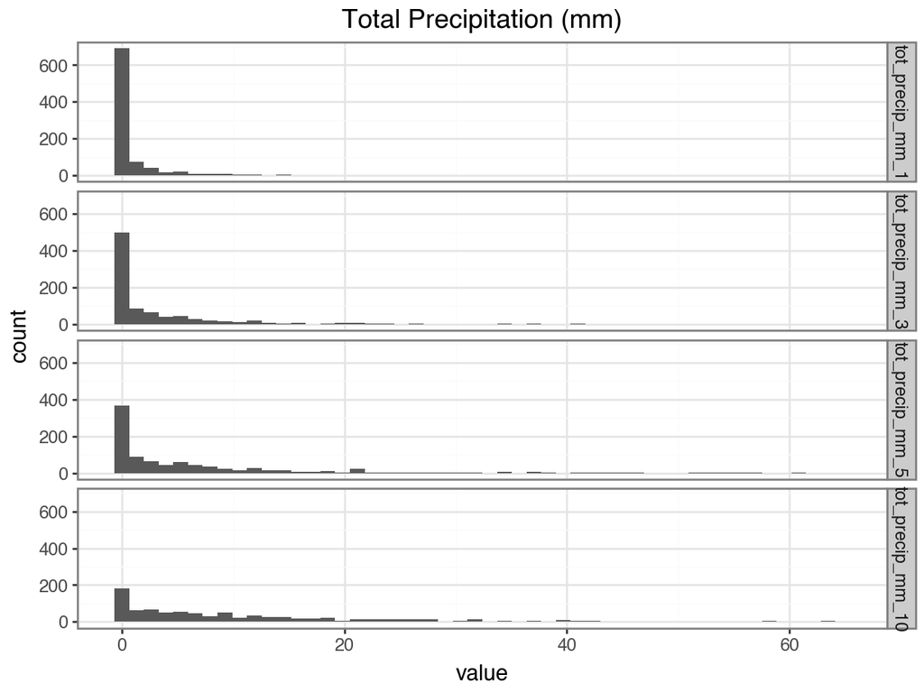

```python
tot_precip = (pd.DataFrame(tv.filter(like='precip').stack())
              .reset_index(drop=False)
              .rename(columns={'level_0':'rowid', 'level_1':'variable', 0:'value'}))
tot_precip['variable'] = tot_precip['variable'].astype('category').cat.reorder_categories(['tot_precip_mm_1', 'tot_precip_mm_3', 'tot_precip_mm_5', 'tot_precip_mm_10'])

(ggplot(tot_precip, aes(x = 'value'))
  + geom_histogram(bins = 50)
  + labs(title = "Total Precipitation (mm)")
  + facet_grid(rows = 'variable')
  + theme_bw()
  )
```

Eep! These are super skewed. For these, we’ll take the log of the value, but first we need to add 0.1 since most of the values are 0 and log+0 don’t play nicely.

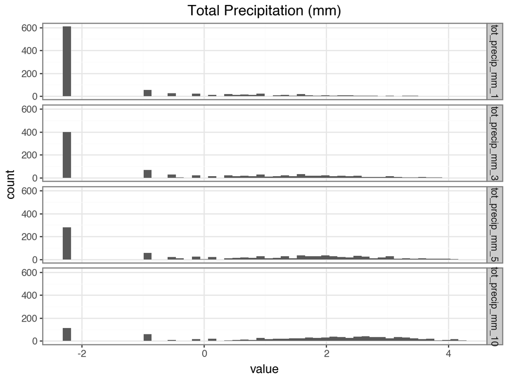

```python
tv_no_precip = tv2.drop(tv2.filter(like = 'precip').columns, axis = 1)
tot_precip = tv.filter(like='precip')
tot_precip += 0.1
tot_precip = np.log(tot_precip)

tv3 = pd.concat([tv_no_precip, tot_precip], axis = 1)

tot_precip = (pd.DataFrame(tv3.filter(like='precip').stack())
              .reset_index(drop=False)
              .rename(columns={'level_0':'rowid', 'level_1':'variable', 0:'value'}))
tot_precip['variable'] = tot_precip['variable'].astype('category').cat.reorder_categories(['tot_precip_mm_1', 'tot_precip_mm_3', 'tot_precip_mm_5', 'tot_precip_mm_10'])

(ggplot(tot_precip, aes(x = 'value'))
  + geom_histogram(bins = 50)
  + labs(title = "Total Precipitation (mm)")
  + facet_grid(rows = 'variable')
  + theme_bw()
  )
```

That’s better, though 0’s are arguably problematic - we may want to change this to categorical later, 0 = no rain, 1 = some rain, 2 = a lot of rain - to help with this issue. For now, we’ll leave it as is.

### Pump

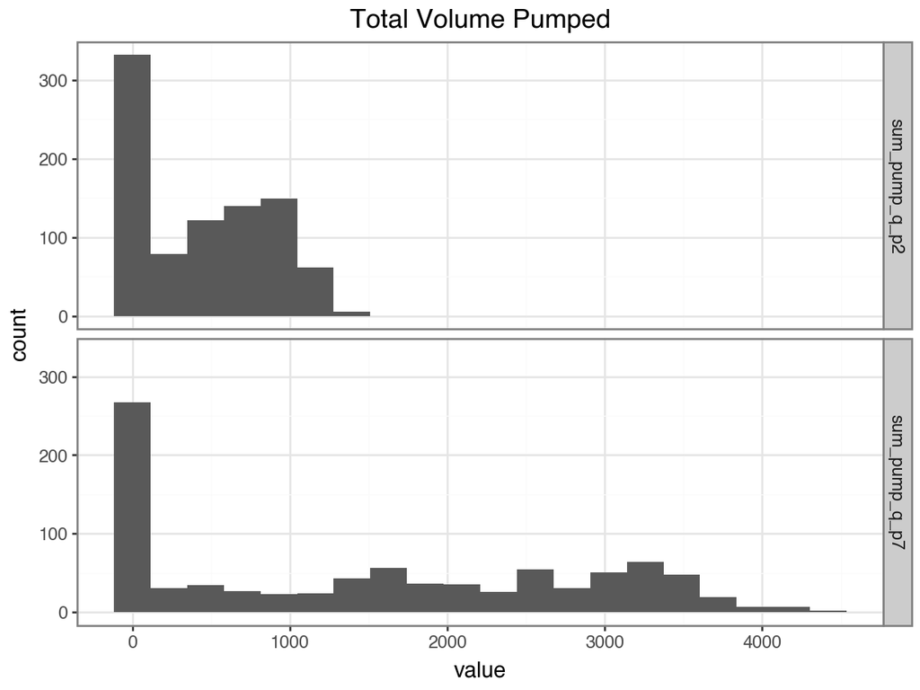

```python
pump = tv.filter(like='pump')
sum_pump = (pd.DataFrame(tv.filter(like='sum_pump').stack())
              .reset_index(drop=False)
              .rename(columns={'level_0':'rowid', 'level_1':'variable', 0:'value'}))
sum_pump['variable'] = sum_pump['variable'].astype('category').cat.reorder_categories(['sum_pump_q_p2', 'sum_pump_q_p7'])
cols_to_keep = [col for col in pump.columns if '_m' in col or 'mean' in col]
mean_pump = (pd.DataFrame(tv[cols_to_keep].stack())
              .reset_index(drop=False)
              .rename(columns={'level_0':'rowid', 'level_1':'variable', 0:'value'}))
mean_pump['variable'] = mean_pump['variable'].astype('category').cat.reorder_categories(['pump_q_m1', 'pump_q_m2', 'mean_pump_q_p2', 'mean_pump_q_p7'])
max_pump = (pd.DataFrame(tv.filter(like='max_pump').stack())
              .reset_index(drop=False)
              .rename(columns={'level_0':'rowid', 'level_1':'variable', 0:'value'}))
max_pump['variable'] = max_pump['variable'].astype('category').cat.reorder_categories(['max_pump_q_p2', 'max_pump_q_p7'])

(ggplot(sum_pump, aes(x = 'value'))
  + geom_histogram(bins = 20)
  + labs(title = "Total Volume Pumped")
  + facet_grid(rows = 'variable')
  + theme_bw()
  )
```

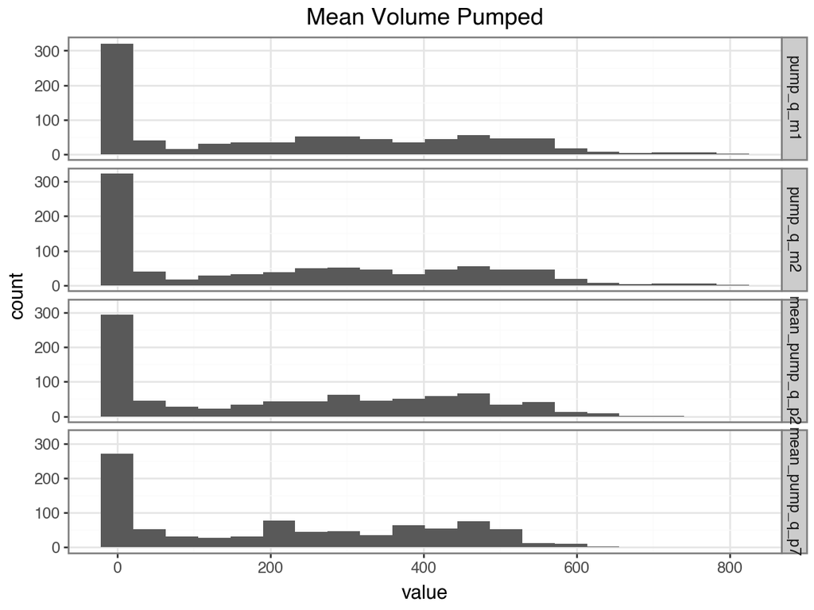

```python
(ggplot(mean_pump, aes(x = 'value'))
  + geom_histogram(bins = 20)
  + labs(title = "Mean Volume Pumped")
  + facet_grid(rows = 'variable')
  + theme_bw()
  )
```

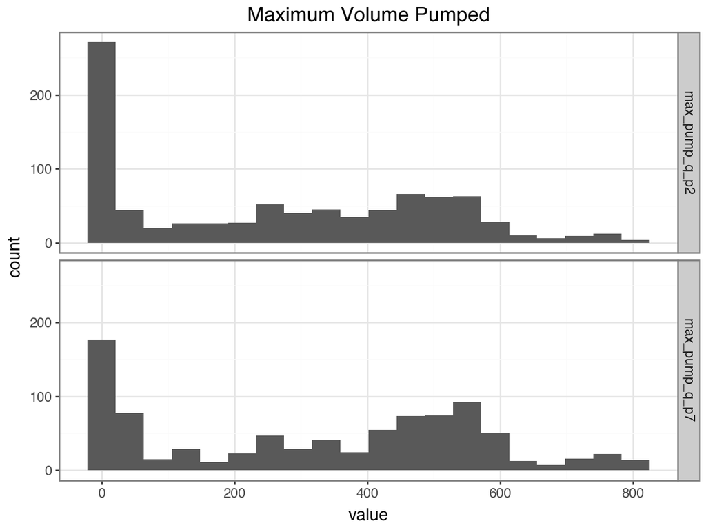

```python
(ggplot(max_pump, aes(x = 'value'))
  + geom_histogram(bins = 20)
  + labs(title = "Maximum Volume Pumped")
  + facet_grid(rows = 'variable')
  + theme_bw()
  )
```

These look fine, even though volume of 0 is prevalent in the dataset.

### Chipmunk

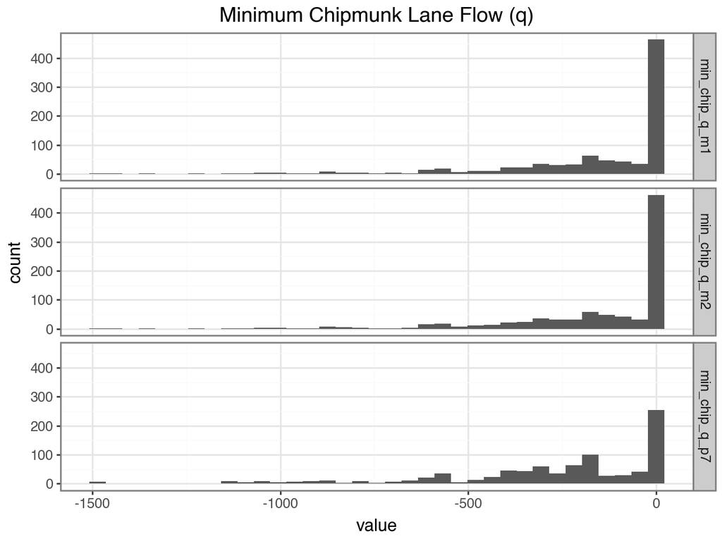

```python
chip = tv.filter(like="chip")
min_chip = (pd.DataFrame(tv.filter(like='min_chip').stack())
              .reset_index(drop=False)
              .rename(columns={'level_0':'rowid', 'level_1':'variable', 0:'value'}))
min_chip['variable'] = min_chip['variable'].astype('category').cat.reorder_categories(['min_chip_q_m1', 'min_chip_q_m2', 'min_chip_q_p7'])
cols_to_keep = [col for col in chip.columns if 'ave' in col or 'mean' in col]
mean_chip = (pd.DataFrame(tv[cols_to_keep].stack())
              .reset_index(drop=False)
              .rename(columns={'level_0':'rowid', 'level_1':'variable', 0:'value'}))
mean_chip['variable'] = mean_chip['variable'].astype('category').cat.reorder_categories(['ave_chip_q_m1', 'ave_chip_q_m2', 'mean_chip_q_p2', 'mean_chip_q_p7'])
max_chip = (pd.DataFrame(tv.filter(like='max_chip').stack())
              .reset_index(drop=False)
              .rename(columns={'level_0':'rowid', 'level_1':'variable', 0:'value'}))
max_chip['variable'] = max_chip['variable'].astype('category').cat.reorder_categories(['max_chip_q_m1', 'max_chip_q_m2', 'max_chip_q_p2', 'max_chip_q_p7'])
sum_chip = (pd.DataFrame(tv.filter(like='sum_chip').stack())
              .reset_index(drop=False)
              .rename(columns={'level_0':'rowid', 'level_1':'variable', 0:'value'}))
sum_chip['variable'] = sum_chip['variable'].astype('category').cat.reorder_categories(['sum_chip_q_p2', 'sum_chip_q_p7'])

(ggplot(min_chip, aes(x = 'value'))
  + geom_histogram()
  + labs(title = "Minimum Chipmunk Lane Flow (q)")
  + facet_grid(rows = 'variable')
  + theme_bw()
  )
```

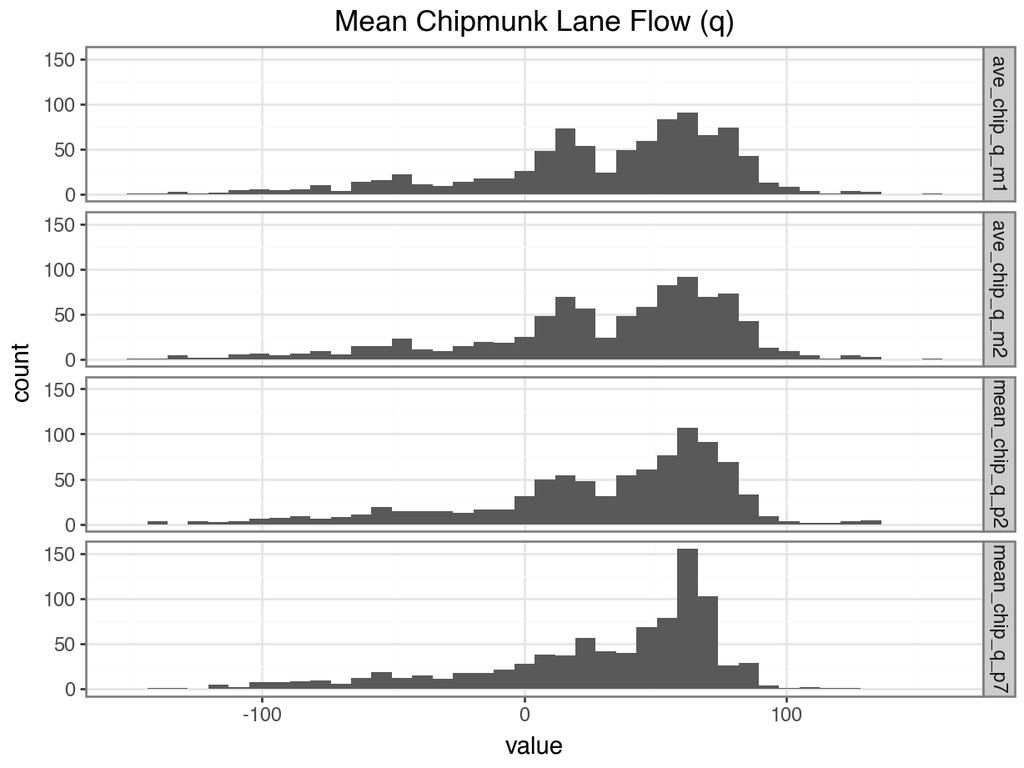

```python
(ggplot(mean_chip, aes(x = 'value'))
  + geom_histogram()
  + labs(title = "Mean Chipmunk Lane Flow (q)")
  + facet_grid(rows = 'variable')
  + theme_bw()
  )
```

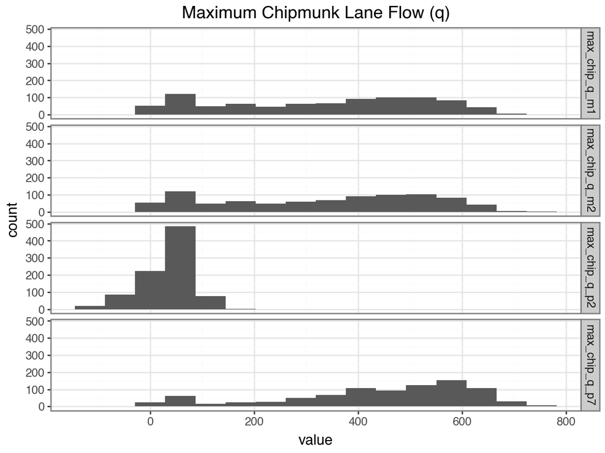

```python
(ggplot(max_chip, aes(x = 'value'))
  + geom_histogram()
  + labs(title = "Maximum Chipmunk Lane Flow (q)")
  + facet_grid(rows = 'variable')
  + theme_bw()
  )
```

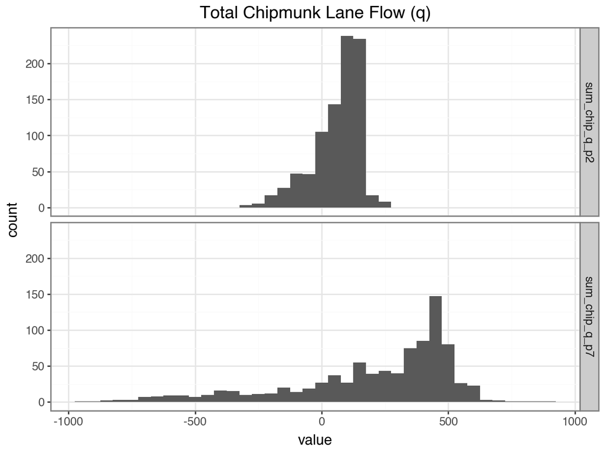

```python
(ggplot(sum_chip, aes(x = 'value'))
  + geom_histogram()
  + labs(title = "Total Chipmunk Lane Flow (q)")
  + facet_grid(rows = 'variable')
  + theme_bw()
  )
```

Minimum flow is pretty skewed. Has a similar issue as precip, so we’ll transform and see how things go in training! Since these values are negative, we need to take the absolute value of them and add 0.1 before transforming. While it’s counter intuitive we will leave the values as-is, since we will still standardize them and ML doesn’t care what the sign of the values are, just the magnitude.

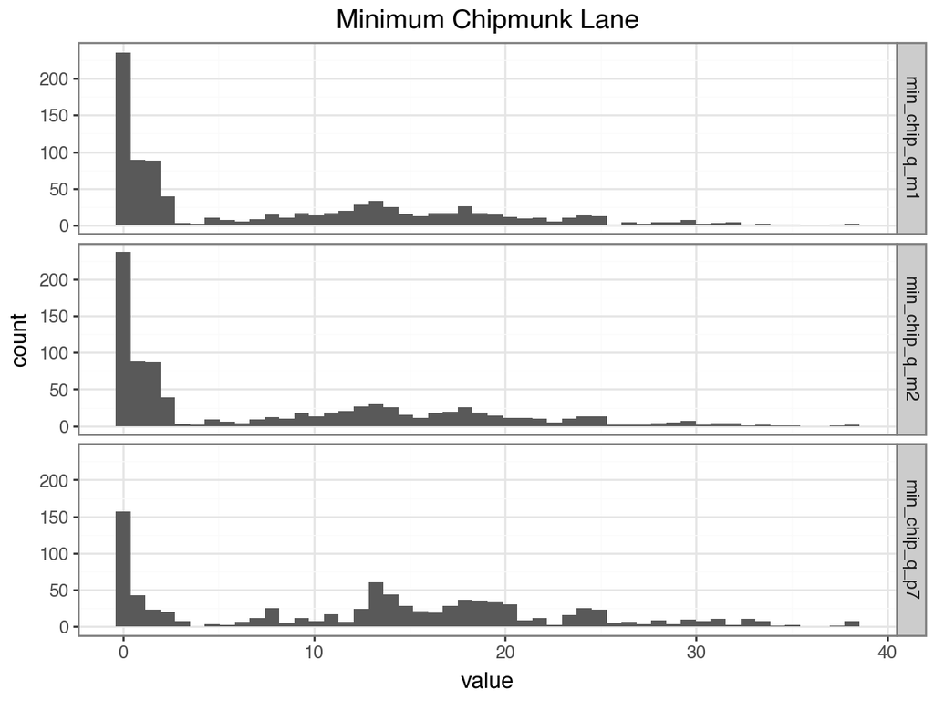

```python
tv_no_minchip = tv3.drop(tv3.filter(like = 'min_chip').columns, axis = 1)
min_chip = tv.filter(like='min_chip')
min_chip = np.abs(min_chip)
min_chip += 0.1
min_chip = np.sqrt(min_chip)

tv4 = pd.concat([tv_no_minchip, min_chip], axis = 1)

min_chip = (pd.DataFrame(tv4.filter(like='min_chip').stack())
              .reset_index(drop=False)
              .rename(columns={'level_0':'rowid', 'level_1':'variable', 0:'value'}))
min_chip['variable'] = min_chip['variable'].astype('category').cat.reorder_categories(['min_chip_q_m1', 'min_chip_q_m2', 'min_chip_q_p7'])

(ggplot(min_chip, aes(x = 'value'))
  + geom_histogram(bins = 50)
  + labs(title = "Minimum Chipmunk Lane")
  + facet_grid(rows = 'variable')
  + theme_bw()
  )
```

A little wacky, but I guess less skewed?

### North Fork

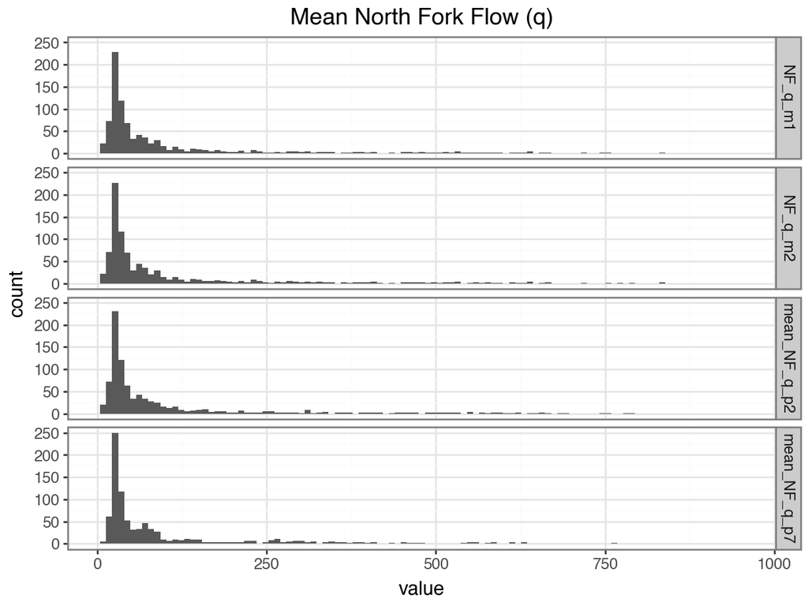

```python
nf = tv.filter(like='NF')
cols_to_keep = [col for col in nf.columns if '_m' in col or 'mean' in col]
mean_nf = (pd.DataFrame(tv[cols_to_keep].stack())
              .reset_index(drop=False)
              .rename(columns={'level_0':'rowid', 'level_1':'variable', 0:'value'}))
mean_nf['variable'] = mean_nf['variable'].astype('category').cat.reorder_categories(['NF_q_m1', 'NF_q_m2', 'mean_NF_q_p2', 'mean_NF_q_p7'])
max_nf = (pd.DataFrame(tv.filter(like='max_NF').stack())
              .reset_index(drop=False)
              .rename(columns={'level_0':'rowid', 'level_1':'variable', 0:'value'}))
max_nf['variable'] = max_nf['variable'].astype('category').cat.reorder_categories(['max_NF_q_p2', 'max_NF_q_p7'])
sum_nf = (pd.DataFrame(tv.filter(like='sum_NF').stack())
              .reset_index(drop=False)
              .rename(columns={'level_0':'rowid', 'level_1':'variable', 0:'value'}))
sum_nf['variable'] = sum_nf['variable'].astype('category').cat.reorder_categories(['sum_NF_q_p2', 'sum_NF_q_p7'])

(ggplot(mean_nf, aes(x = 'value'))
  + geom_histogram()
  + labs(title = "Mean North Fork Flow (q)")
  + facet_grid(rows = 'variable')
  + theme_bw()
  )
```

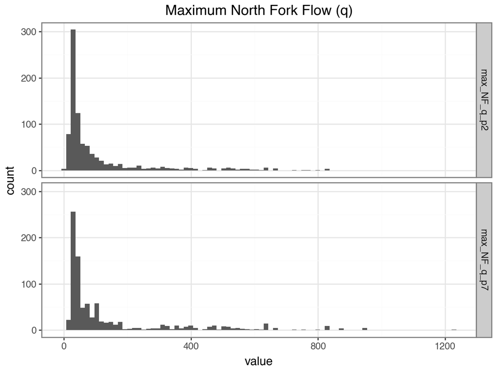

```python
(ggplot(max_nf, aes(x = 'value'))
  + geom_histogram()
  + labs(title = "Maximum North Fork Flow (q)")
  + facet_grid(rows = 'variable')
  + theme_bw()
  )
```

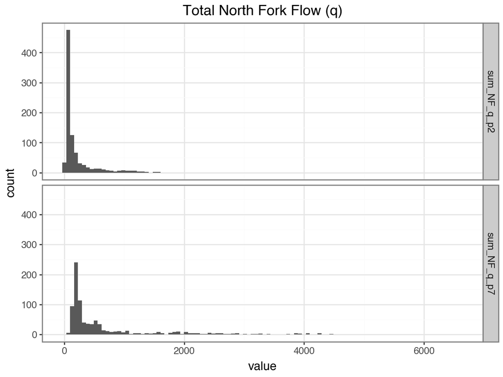

```python
(ggplot(sum_nf, aes(x = 'value'))
  + geom_histogram()
  + labs(title = "Total North Fork Flow (q)")
  + facet_grid(rows = 'variable')
  + theme_bw()
  )
```

These definitely need to be transformed!

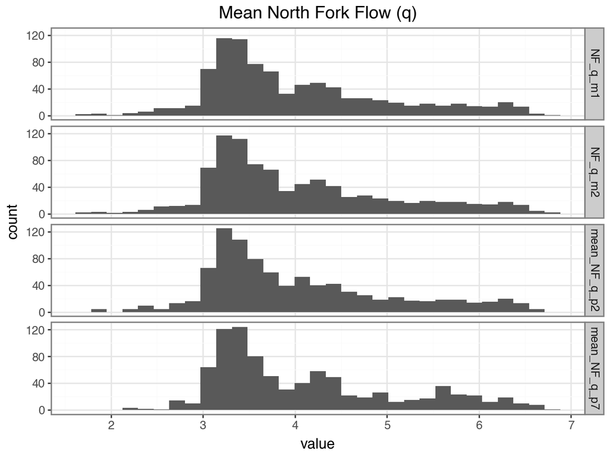

```python
tv_no_NF = tv4.drop(nf.columns, axis = 1)
nf = np.log(nf)

tv5 = pd.concat([tv_no_NF, nf], axis = 1)

cols_to_keep = [col for col in nf.columns if '_m' in col or 'mean' in col]
mean_nf = (pd.DataFrame(tv5[cols_to_keep].stack())
              .reset_index(drop=False)
              .rename(columns={'level_0':'rowid', 'level_1':'variable', 0:'value'}))
mean_nf['variable'] = mean_nf['variable'].astype('category').cat.reorder_categories(['NF_q_m1', 'NF_q_m2', 'mean_NF_q_p2', 'mean_NF_q_p7'])
max_nf = (pd.DataFrame(tv5.filter(like='max_NF').stack())
              .reset_index(drop=False)
              .rename(columns={'level_0':'rowid', 'level_1':'variable', 0:'value'}))
max_nf['variable'] = max_nf['variable'].astype('category').cat.reorder_categories(['max_NF_q_p2', 'max_NF_q_p7'])
sum_nf = (pd.DataFrame(tv5.filter(like='sum_NF').stack())
              .reset_index(drop=False)
              .rename(columns={'level_0':'rowid', 'level_1':'variable', 0:'value'}))
sum_nf['variable'] = sum_nf['variable'].astype('category').cat.reorder_categories(['sum_NF_q_p2', 'sum_NF_q_p7'])

(ggplot(mean_nf, aes(x = 'value'))
  + geom_histogram()
  + labs(title = "Mean North Fork Flow (q)")
  + facet_grid(rows = 'variable')
  + theme_bw()
  )
```

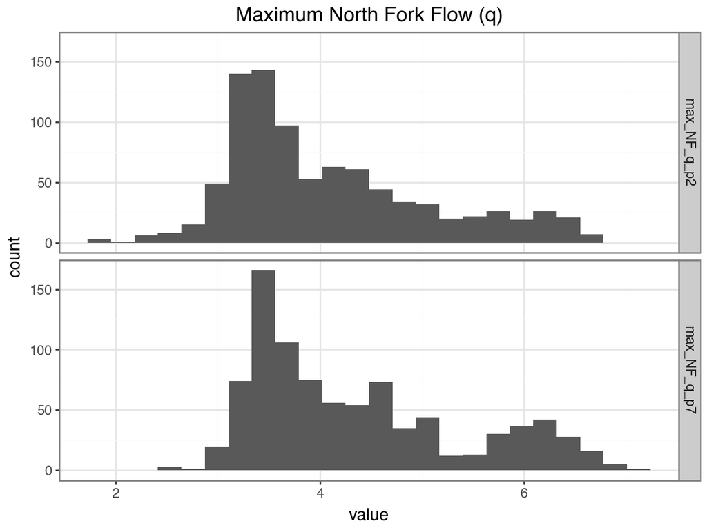

```python
(ggplot(max_nf, aes(x = 'value'))
  + geom_histogram()
  + labs(title = "Maximum North Fork Flow (q)")
  + facet_grid(rows = 'variable')
  + theme_bw()
  )
```

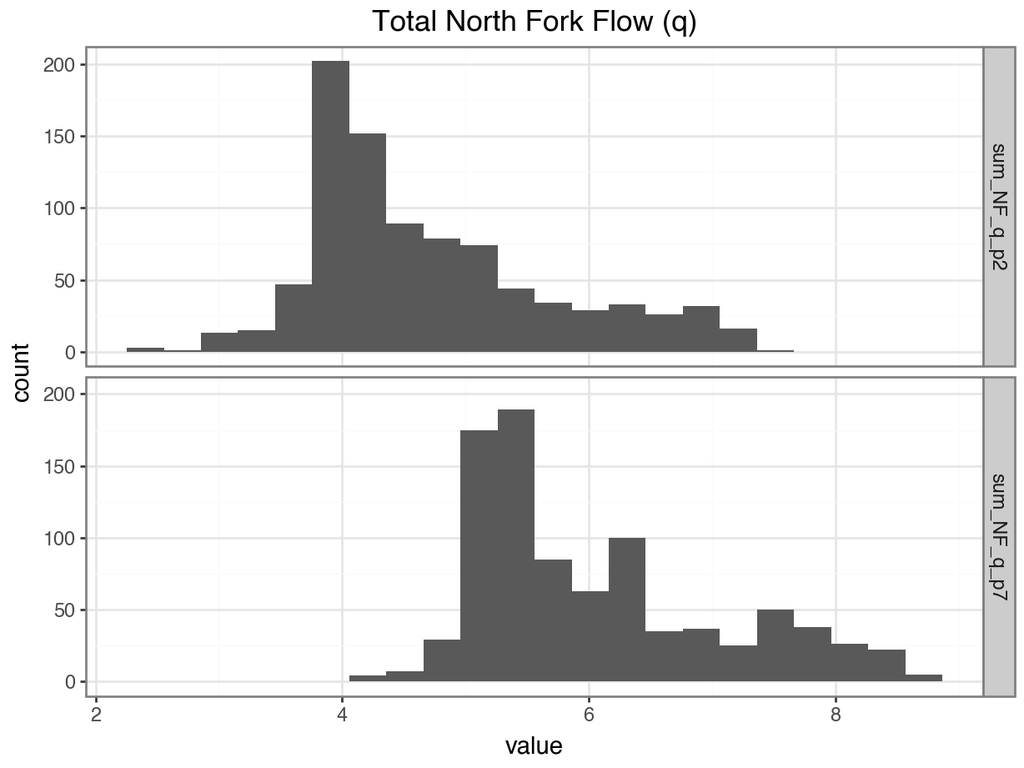

```python
(ggplot(sum_nf, aes(x = 'value'))
  + geom_histogram()
  + labs(title = "Total North Fork Flow (q)")
  + facet_grid(rows = 'variable')
  + theme_bw()
  )
```

Much better.

### Res level

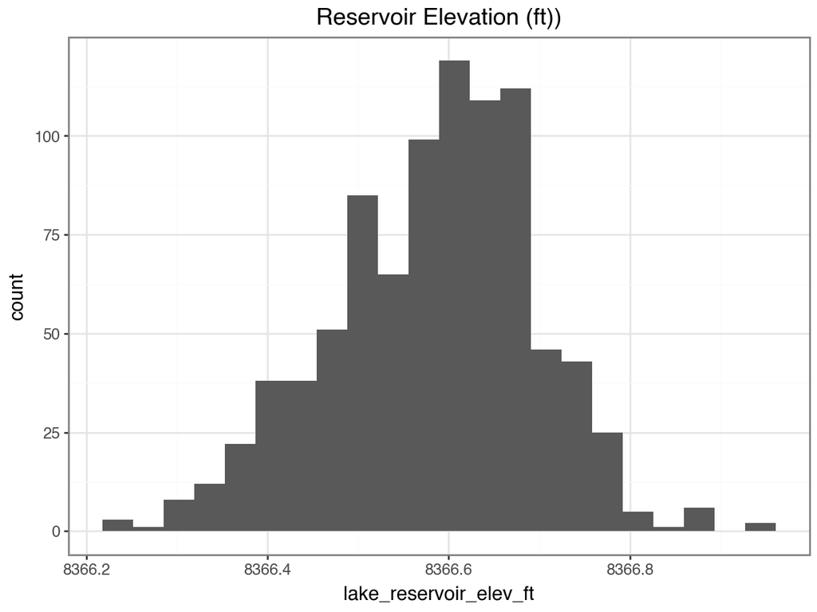

```python
(ggplot(tv, aes(x='lake_reservoir_elev_ft'))
  + geom_histogram()
  + labs(title = "Reservoir Elevation (ft))")
  + theme_bw()
  )
```

This is fine too.

Let’s do a quick sanity check to make sure we haven’t created any additional columns or rows:

```python
tv.shape
```

```
## (890, 71)
```

```python
tv5.shape
```

```
## (890, 71)
```

Great!

# Standardize the data

To standardize the data around 0, we’ll use the mean and standard deviation:

```python
def standardize_column(df, col_name):
    col = df[col_name]
    return (col - col.mean()) / col.std()
```

Before we apply, we want to make a copy of this dataframe and drop the dates from it.

```python
tv_short = tv5.copy()
tv_short = tv_short.drop('date', axis = 1)
```

And now apply the function:

```python
tv_standardized = tv_short.apply(lambda col: standardize_column(tv_short, col.name))
```

Because we want to be able to apply these same standardizations to the test data, we should grab the mean/std values for each column:

```python
tv_mean_std = pd.DataFrame({'mean': tv_short.mean(), 'std': tv_short.std()})
```

Lets save this as a .csv file for later use

```python
file_name = "mean_std_train_val_t2023_v" + standardize_version + ".csv"
# join with file path
fp = os.path.join(file_path, file_name)
# and save
tv_mean_std.to_csv(fp, index=True)
```

# Split Training/Validation

Our training data are now ready to be split into training and validation sets.

```python
training = tv_standardized.copy()

# but let's add lake and date back in.
training = training.join(tv5[['date']])
```

We’ll do timeseries cross validation here.

```python
training['date'] = pd.to_datetime(training['date'])
training['date'].min()
```

```
## Timestamp('2014-06-12 00:00:00+0000', tz='UTC')
```

```python
training['date'].max()
```

```
## Timestamp('2022-10-02 00:00:00+0000', tz='UTC')
```

Looks like it’s 8 years of data, let’s break this by year.

```python
start_year = pd.to_datetime('2014-01-01', utc = True)
end_year = pd.to_datetime('2023-01-01', utc = True)

years = pd.date_range(start_year, end_year, freq ='1YS', inclusive = 'left')

def save_csv(data, data_name, filepath):
  file_name = data_name + "_v" + standardize_version +".csv"
  # join with file path
  fp = os.path.join(filepath, file_name)
  # and save
  data.to_csv(fp, index=False)


for y in years:
  val = training.loc[training['date'].between(y, y + pd.tseries.offsets.DateOffset(years = 1))]
  train = training.merge(val, how='outer', indicator=True).query('_merge=="left_only"').drop('_merge', axis=1)
  if (val.shape[1] == train.shape[1]) & (val.shape[0] + train.shape[0] == training.shape[0]):
    # subset for only reg duration
    start_reg = pd.to_datetime((dt.datetime.strftime(y, '%Y') + '-07-01'), utc = True)
    end_reg = pd.to_datetime((dt.datetime.strftime(y, '%Y') + '-09-11'), utc = True)
    val['date'] = pd.to_datetime(val['date'])
    val = val.loc[val['date'].between(start_reg, end_reg, inclusive = 'both')]
    # save files
    save_csv(val, 'validation_t2023_' + dt.datetime.strftime(y, '%Y'), file_path)
    save_csv(train, 'training_t2023_' + dt.datetime.strftime(y, '%Y'), file_path)
  else:
    print('There is an issue with the shape of your training and validation sets')
```

[output not shown]